# Mexican maize landraces can be distinguished by few SNPs, but broad genomic diversity related to environmental and bio-cultural factors underlies their phenotypic diversity

Caldú-Primo JL., Wegier A., Mastretta A., Piñero D.

### Set working directories and relevant libraries.

SNP data should be saved in your working directory.

```r
WD <- "/home/user/Escritorio/Biologia/TESIS/Datos_Maiz/DATA/"

## Load required libraries
library (adegenet)
```

```
##
##    /// adegenet 2.0.0 is loaded ////////////
##
##    > overview: '?adegenet'
##    > tutorials/doc/questions: 'adegenetWeb()'
##    > bug reports/feature resquests: adegenetIssues()
```

```r
library(poppr)
library(ape)
library(NMF)
library(snpStats)
```

```r
library(ggplot2)
library(gdsfmt)
library(SNPRelate)
library(grid)
library(gridExtra)
## Load SNP data
bed<-paste(WD,"/maiz_listo.bed",sep="")
bim<-paste(WD,"/maiz_listo.bim",sep="")
fam<-paste(WD,"/maiz_listo.fam",sep="")
ped<-paste(WD,"/maiz_listo.ped",sep="")
raw<-paste(WD,"/maiz_listo.raw",sep="")
map <-paste(WD, "/maiz_listo.map",sep="")

## Load sample data
subject.support<-read.csv(paste(WD,"/subject.support.csv",sep=""),header=TRUE)
# Load information about domestication and improvement SNPs
snpsextract<-read.csv(paste(WD,"/snp.support.csv",sep=""),header=TRUE)
```

### Integrate data

Prepare SNP data for its handling with SNPStats, SNPRelate and Adegenet packages

```r
## Integrate SNP data for SNPStats package handling
maiz<-read.plink(bed,bim,fam)
snps<-maiz$genotype
snp.support<-maiz$map
## Integrate SNP data for Adegenet package handling
maizgl <- read.PLINK(file=raw,mapfile=map)
```

```
##
##  Reading PLINK raw format into a genlight object...
##
##
##  Reading loci information...
##
##  Reading and converting genotypes...
## .
##  Building final object...
##
## ...done.
```

```r
## Remove duplicated SNPs
glmatrix <- as.matrix(maizgl)
glmatrix <- glmatrix[,-grep("HET",colnames(glmatrix))]
maizgl<-as.genlight(glmatrix)

## Integrate data for SNPRelate package handling
snpgdsBED2GDS(bed,fam,bim,out.gdsfn ="maiz.listo.gds")
```

```
## Start snpgdsBED2GDS ...
##  BED file: "/home/user/Escritorio/Biologia/TESIS/Datos_Maiz/DATA//maiz_listo.bed" in the SNP-major mode (Sample X SNP)
##  FAM file: "/home/user/Escritorio/Biologia/TESIS/Datos_Maiz/DATA//maiz_listo.fam", DONE.
##  BIM file: "/home/user/Escritorio/Biologia/TESIS/Datos_Maiz/DATA//maiz_listo.bim", DONE.
## Wed Nov 30 08:48:44 2016     store sample id, snp id, position, and chromosome.
##  start writing: 50 samples, 46518 SNPs ...
##      Wed Nov 30 08:48:44 2016    0%
##      Wed Nov 30 08:48:45 2016    100%
## Wed Nov 30 08:48:45 2016     Done.
## Optimize the access efficiency ...
## Clean up the fragments of GDS file:
##  open the file "maiz.listo.gds" (size: 876776).
##  # of fragments in total: 39.
##  save it to "maiz.listo.gds.tmp".
##  rename "maiz.listo.gds.tmp" (size: 876524).
##  # of fragments in total: 18.
```

```r
genofile <- snpgdsOpen("maiz.listo.gds")

snpset <- snpgdsLDpruning(genofile,ld.threshold = 1, autosome.only=F) ## Remove monomorphic SNPs
```

```
## SNP pruning based on LD:
## Excluding 3064 SNPs (monomorphic: TRUE, < MAF: NaN, or > missing rate: NaN)
## Working space: 50 samples, 43454 SNPs
##  Using 1 (CPU) core
##  Sliding window: 500000 basepairs, Inf SNPs
##  |LD| threshold: 1
## Chromosome 1: 88.12%, 4991/5664
## Chromosome 2: 87.10%, 2019/2318
## Chromosome 3: 91.00%, 4528/4976
## Chromosome 4: 87.99%, 4336/4928
## Chromosome 5: 89.79%, 4379/4877
## Chromosome 6: 88.38%, 3112/3521
## Chromosome 7: 91.01%, 3292/3617
## Chromosome 8: 89.76%, 3375/3760
## Chromosome 9: 88.96%, 2918/3280
## Chromosome 10: 89.13%, 2869/3219
## 35819 SNPs are selected in total.
```

```r
snpset.id <- unlist(snpset) #get all selected snp id
```

### Define the SNP sets:

- Domestication and improvement SNPs -> Information about the domestication and improvement SNPs has already been loaded in the snpsextract table. They only have to be extracted from the SNP matrix.

```r
## Subset SNP matrix keeping only Domestication and improvement SNPs
glmatrixdom <- glmatrix[, pmatch(snpsextract[,2],colnames(glmatrix))]
glmatrixdom <- glmatrixdom[, colSums(is.na(glmatrixdom)) != nrow(glmatrixdom)]
```

- High $F_{ST}$ SNPs -> Calculate the $F_{ST}$ index for every SNP among races.

```r
### Fst measurement for every SNP among races, keeping SNP name and removing NAs
fraza <- Fst (snps,subject.support[,'raza'])
names(fraza$Fst)<-colnames(snps)
fraza$Fst<-fraza$Fst[!is.na(fraza$Fst)]
```

```
Identify the 1% of SNPs with higher $F_{ST}$  to be extracted from the SNP matrix.
```

```r
### function to identify SNPs with an Fst value higher than certain percent treshold. Takes as input a named vector with the Fst value for SNPs and a givena treshold.
fst.alta <- function (snpsfst, percent){
  alta <- quantile(snpsfst,probs=percent) ## get the Fst value corresponding to the treshold percent
  fst.snp <- data.frame (SNPs=c(1:length(snpsfst[snpsfst>=0])), Fst = snpsfst[snpsfst>=0], Dif = snpsfst[snpsfst>=0]>alta) # data frame with all the SNPs with a column (Dif) indicating if they have Fst above or below the treshold
  snps.alta <- snpsfst[snpsfst>alta] # names of SNPs above the Fst treshold
  return(list(Fst.value=alta, snp.info=snps.alta,fst.snp=fst.snp))
}
#########################################################################3
## Identify high Fst SNPs among races
raza.99<-fst.alta(fraza$Fst,.99)
snps_Fstalta<-data.frame(names(raza.99$snp.info))
###########################################################################
### Subset SNP matrix keeping only landrace high Fst  SNPs
snpsfst99 <- names(raza.99$snp.info)
glmatrixfst <- glmatrix[, pmatch(snpsfst99, colnames(glmatrix))]
glmatrixfst <- glmatrixfst[, colSums(is.na(glmatrixfst)) != nrow(glmatrixfst)]
```

### PCA of the three SNP sets

```r
#### Function to create PCA using a given set SNPs and grouping of samples.
PCA <- function(genofile, grouping, snps=snpset.id){
  used.snps <- snps[match(snpset.id,snps)]
  used.snps <- used.snps[complete.cases(used.snps)]
  pca <- snpgdsPCA (genofile, snp.id=used.snps)

  pc.percent<- pca$varprop*100

  col<-c("red","gold","green3","dodgerblue","magenta4")
  sample.id <- read.gdsn (index.gdsn(genofile, "sample.id"))
  pop_code <- as.vector (subject.support[,grouping])
  tab <- data.frame (sample.id=pca$sample.id,
                     Landrace=factor(pop_code)[match(pca$sample.id, sample.id)],
                     PC1 = pca$eigenvect[,1], PC2 = pca$eigenvect[,2],
                     stringsAsFactors = FALSE)
  plot <- ggplot(tab, aes(x=PC2, y=PC1, colour=Landrace)) + geom_point(shape=19)+ scale_colour_manual(values = col)+theme_bw()
  return(list(PCA=pca,PCpercent=pc.percent,table=tab,grafica=plot,snps=used.snps))
}
##############################################################
snpsdom <- as.character(snpsextract[,2])
snpsdom <- snpsdom[match(snpset.id,snpsdom)] ## select the domestication snps present in the snpset
snpsdom <- snpsdom[complete.cases(snpsdom)]

snpsfst99 <- names(raza.99$snp.info) ## names of high Fst SNPs

pca.all.raza <- PCA(genofile=genofile, snps = snpset.id, grouping = 'raza') # PCA with all SNPs
```

```
## Principal Component Analysis (PCA) on SNP genotypes:
## Excluding 10699 SNPs on non-autosomes
## Excluding 0 SNP (monomorphic: TRUE, < MAF: NaN, or > missing rate: NaN)
## Working space: 50 samples, 35819 SNPs
##  Using 1 (CPU) core
## PCA: the sum of all working genotypes (0, 1 and 2) = 859811
## PCA: Wed Nov 30 08:48:48 2016    0%
## PCA: Wed Nov 30 08:48:48 2016    100%
## PCA: Wed Nov 30 08:48:48 2016    Begin (eigenvalues and eigenvectors)
## PCA: Wed Nov 30 08:48:48 2016    End (eigenvalues and eigenvectors)
```

```r
pca.dom.raza <- PCA(genofile=genofile, snps = snpsdom, grouping = 'raza')# PCA with domestication and improvement SNPs
```

```
## Principal Component Analysis (PCA) on SNP genotypes:
## Excluding 45969 SNPs on non-autosomes
## Excluding 0 SNP (monomorphic: TRUE, < MAF: NaN, or > missing rate: NaN)
## Working space: 50 samples, 549 SNPs
##  Using 1 (CPU) core
## PCA: the sum of all working genotypes (0, 1 and 2) = 12674
## PCA: Wed Nov 30 08:48:48 2016    0%
## PCA: Wed Nov 30 08:48:48 2016    100%
## PCA: Wed Nov 30 08:48:48 2016    Begin (eigenvalues and eigenvectors)
## PCA: Wed Nov 30 08:48:48 2016    End (eigenvalues and eigenvectors)
```

```r
pca.fst99.raza <- PCA(genofile=genofile, snps = snpsfst99, grouping = 'raza') # PCA with high Fst SNPs
```

```
## Principal Component Analysis (PCA) on SNP genotypes:
## Excluding 46158 SNPs on non-autosomes
## Excluding 0 SNP (monomorphic: TRUE, < MAF: NaN, or > missing rate: NaN)
## Working space: 50 samples, 360 SNPs
##  Using 1 (CPU) core
## PCA: the sum of all working genotypes (0, 1 and 2) = 7693
## PCA: Wed Nov 30 08:48:48 2016    0%
## PCA: Wed Nov 30 08:48:48 2016    100%
## PCA: Wed Nov 30 08:48:48 2016    Begin (eigenvalues and eigenvectors)
## PCA: Wed Nov 30 08:48:48 2016    End (eigenvalues and eigenvectors)
```

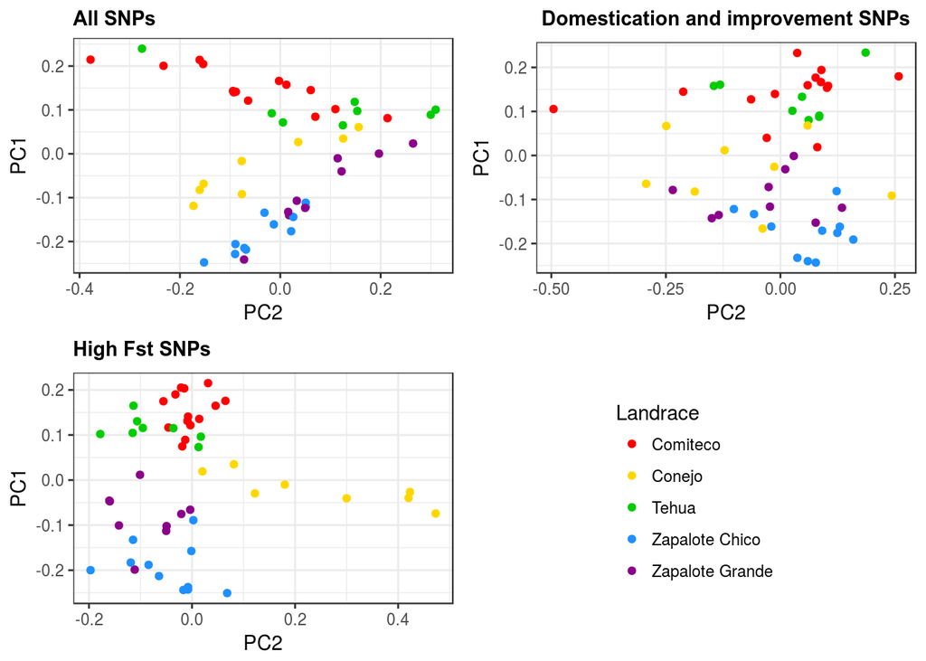

```r
# PCA graphs
all<-pca.all.raza$grafica+ theme(legend.position="", plot.title = element_text(family="Arial", face="bold",size=11))+ggtitle("All SNPs")
dom<-pca.dom.raza$grafica+ theme(legend.position="", plot.title = element_text(family="Arial", face="bold",size=11))+ggtitle(" Domestication and improvement SNPs")
fst<-pca.fst99.raza$grafica +ggtitle("High Fst SNPs")+theme(legend.position="", plot.title = element_text(family="Arial", face="bold",size=11))

g_legend<-function(a.gplot){
    tmp <- ggplot_gtable(ggplot_build(a.gplot))
    leg <- which(sapply(tmp$grobs, function(x) x$name) == "guide-box")
    legend <- tmp$grobs[[leg]]
    legend
}

legend <- g_legend(pca.fst99.raza$grafica)

grid.arrange(all,dom,fst,legend,ncol=2,nrow=2)
```

## Clustering analysis

k-means clustering using the three SNP sets to analyze which set better recovers the landrace groups.

```r
######### Clustering
gldom <- as.genlight(glmatrixdom)
glfst <- as.genlight(glmatrixfst,centers=3)

set.seed(12)
allclusters <- find.clusters.genlight(maizgl,n.pca = 48)
```

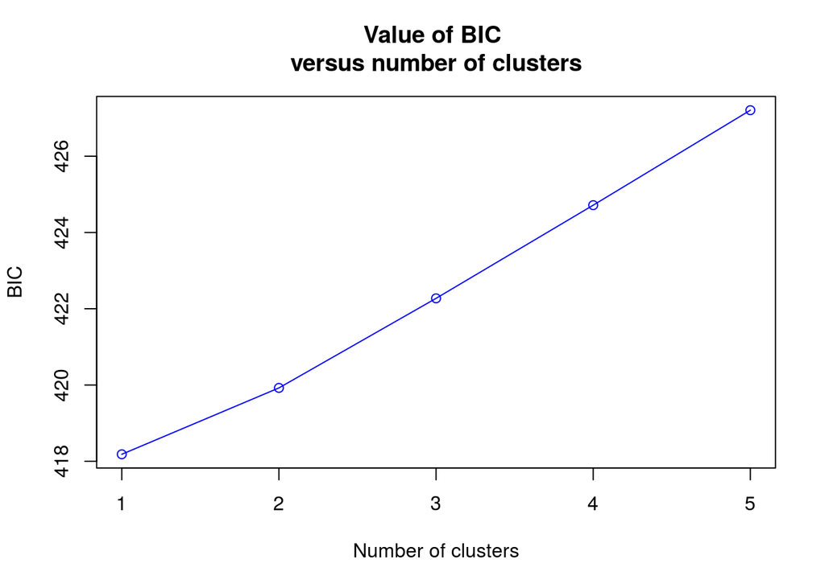

```
## Choose the number of clusters (>=2:
```

```r
domclusters <- find.clusters.genlight(gldom,n.pca = 48)
```

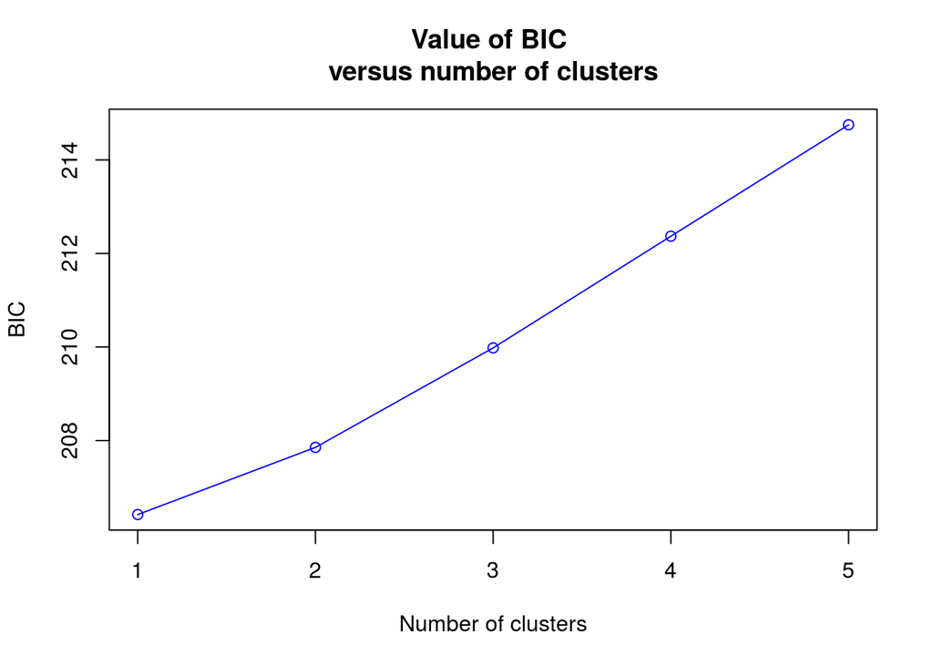

```
## Choose the number of clusters (>=2:
```

```r
fstclusters <- find.clusters.genlight(glfst,n.pca = 48)
```

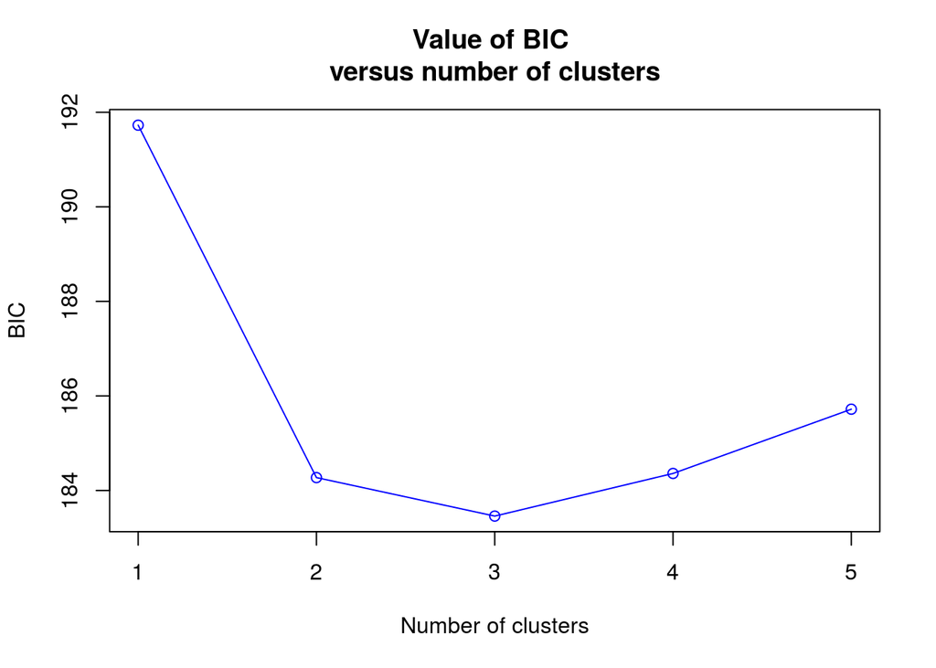

```
## Choose the number of clusters (>=2:
```

The set of all SNPs and domestication and improvement SNPs result in the best model cluster consisting of only one group of samples. The high $F_{ST}$ SNPs set is the only one that generates clusters from k-means modeling, it creates three clusters:

```r
fstclusters <- find.clusters.genlight(glfst,n.pca = 48, n.clust = 3)
tab<-data.frame(Sample=rownames(glmatrix),Cluster=fstclusters$grp, Landrace=subject.support[,'raza'])
tab<-tab[order(tab[,'Cluster'], tab[,'Landrace']),]
tab
```

```
##            Sample Cluster        Landrace
## 14_2166   14_2166       1        Comiteco
## 8_805       8_805       1        Comiteco
## 9_1058     9_1058       1        Comiteco
## 17_10037 17_10037       1        Comiteco
## 37_3052   37_3052       1        Comiteco
## 32_26872 32_26872       1        Comiteco
## 33_29890 33_29890       1        Comiteco
## 35_29971 35_29971       1        Comiteco
## 36_30008 36_30008       1        Comiteco
## maiz_82   maiz_82       1        Comiteco
## maiz_80   maiz_80       1        Comiteco
## maiz_150 maiz_150       1        Comiteco
## maiz_186 maiz_186       1        Comiteco
## maiz_183 maiz_183       1        Comiteco
## 13_1861   13_1861       1           Tehua
## 20_13297 20_13297       1           Tehua
## 6_777       6_777       1           Tehua
## 12_1849   12_1849       1           Tehua
## 31_25784 31_25784       1           Tehua
## 30_23861 30_23861       1           Tehua
## maiz_124 maiz_124       1           Tehua
## maiz_125 maiz_125       1           Tehua
## 7_802       7_802       2  Zapalote Chico
## 19_10473 19_10473       2  Zapalote Chico
## 15_2270   15_2270       2  Zapalote Chico
## 22_23130 22_23130       2  Zapalote Chico
## 23_23142 23_23142       2  Zapalote Chico
## 18_10463 18_10463       2  Zapalote Chico
## 26_23547 26_23547       2  Zapalote Chico
## 28_23597 28_23597       2  Zapalote Chico
## 34_29952 34_29952       2  Zapalote Chico
## 29_25029 29_25029       2  Zapalote Chico
## 25_23217 25_23217       2 Zapalote Grande
## 1_33         1_33       3          Conejo
## 2_44         2_44       3          Conejo
## 3_68         3_68       3          Conejo
## 5_168       5_168       3          Conejo
## maiz_21   maiz_21       3          Conejo
## maiz_23   maiz_23       3          Conejo
## maiz_152 maiz_152       3          Conejo
## maiz_182 maiz_182       3          Conejo
## maiz_142 maiz_142       3  Zapalote Chico
## 21_16210 21_16210       3 Zapalote Grande
## 4_137       4_137       3 Zapalote Grande
## 16_2601   16_2601       3 Zapalote Grande
## 10_1222   10_1222       3 Zapalote Grande
## 11_1773   11_1773       3 Zapalote Grande
## 24_25020 24_25020       3 Zapalote Grande
## 27_23552 27_23552       3 Zapalote Grande
## maiz_144 maiz_144       3 Zapalote Grande
```

## DAPC with high Fst SNPs

Generate the DAPC classification model using the high $F_{ST}$ SNPs set and the landrace assignment

```r
######### DAPC
maizclusters <- as.numeric(as.factor(subject.support[,'raza'])) ## define groups by landrace analysis
names(maizclusters)<-rownames(glmatrix)
maizclusters<-as.factor(maizclusters)

dapc.fst <- dapc.genlight(glfst,maizclusters,n.pca=4,n.da=2)
temp <- optim.a.score(dapc.fst) # analysis to select the correct number of PCA to use in the DAPC
```

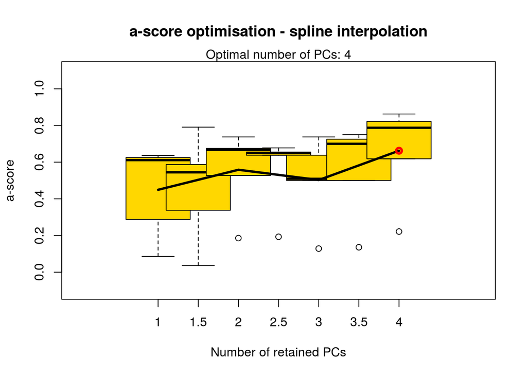

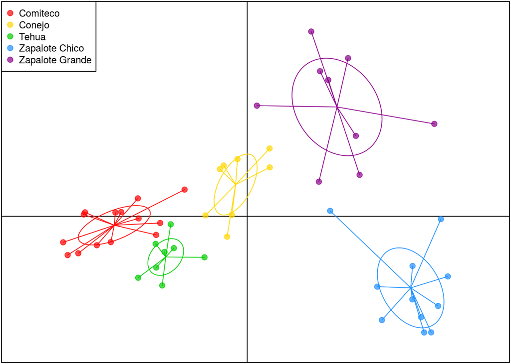

```r
col<-c("red","gold","green3","dodgerblue","magenta4")
scatter(dapc.fst,col=col ,bg="white",cstar=1,scree.da=FALSE, solid=.7, cex=1.5, clab=0, leg=TRUE, txt.leg=c("Comiteco","Conejo","Tehua", "Zapalote Chico", "Zapalote Grande"),posi.leg = "topleft",cleg=.8,cellipse=1)
```

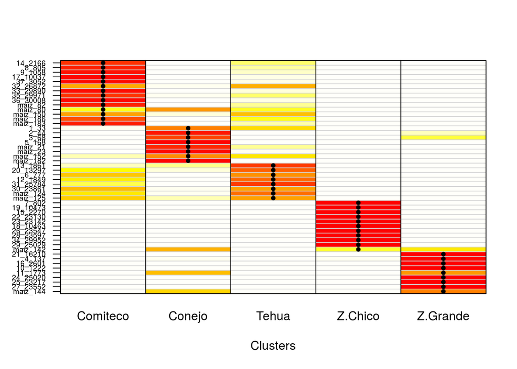

```r
colnames(dapc.fst$posterior)<-c("Comiteco","Conejo","Tehua","Z.Chico","Z.Grande")
dapc.fst$posterior<-cbind(dapc.fst$posterior, subject.support[,"raza"]) ## order samples by landrace for plotting
dapc.fst$posterior<-dapc.fst$posterior[order(dapc.fst$posterior[,6]),]
dapc.fst$posterior<-dapc.fst$posterior[,-6]

par(xpd=F)
assignplot(dapc.fst,cex.lab=.6)
points(x=sort(as.integer(subject.support[,"raza"])),y=seq(49.5,.5,-1),pch=20)
```

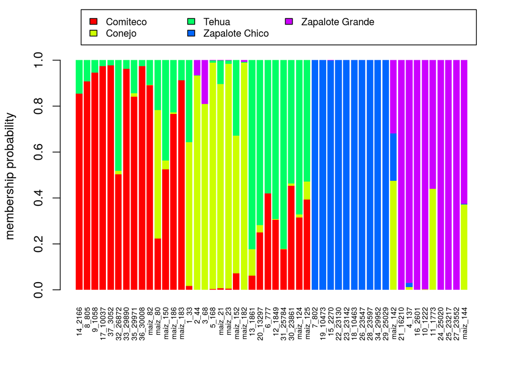

```r
compoplot(dapc.fst,lab=rownames(dapc.fst$posterior), txt.leg=levels(subject.support[,"raza"]),cex.names=0.6,posi=1.22)
```

## Identify landrace informative SNPs

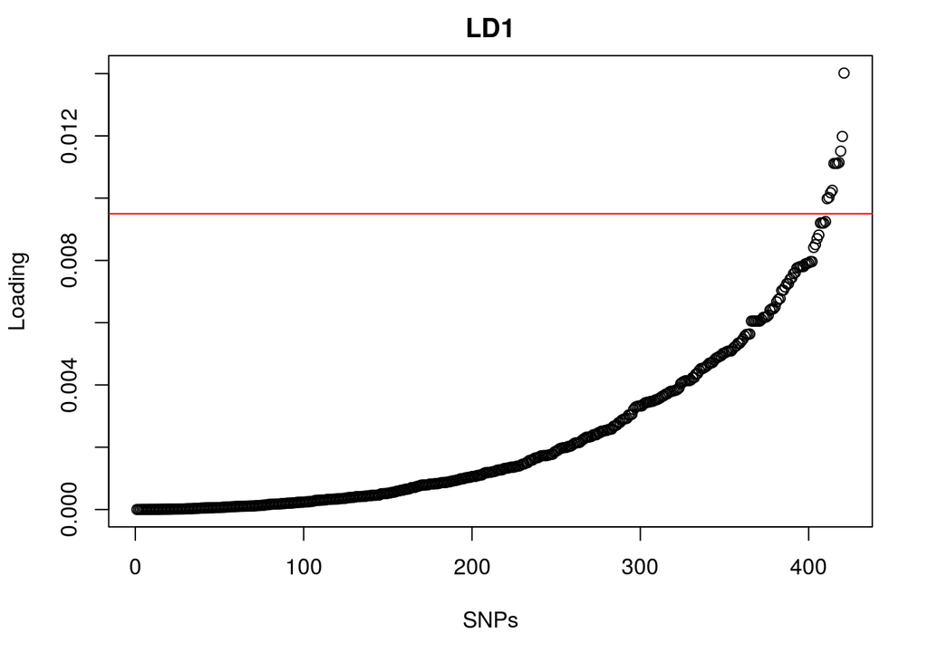

```r
rownames(dapc.fst$var.contr)<-colnames(glmatrixfst)

par(mfrow=c(1,1),mar=c(5.1,4.1,2.1,2.1))
plot(sort(dapc.fst$var.contr[,"LD1"]),xlab="SNPs",ylab="Loading", main="LD1")
abline(h=0.0095, col="red")
```

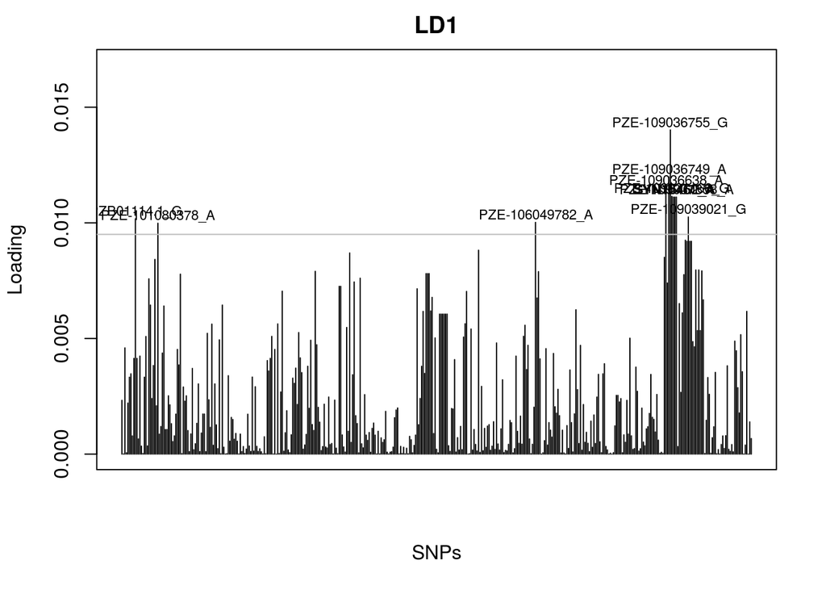

```r
loci_x<-loadingplot (dapc.fst$var.contr,threshold = 0.0095, lab.jitter = 1, axis=1,xlab="SNPs",ylab="Loading",main="LD1")
```

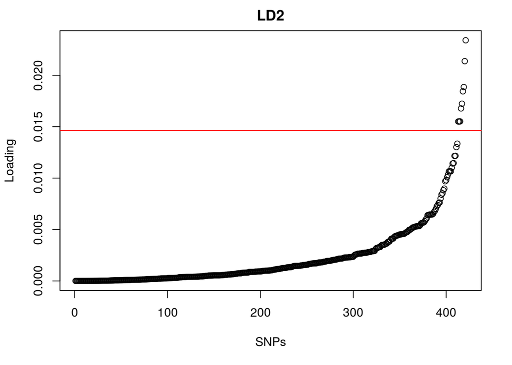

```r
plot(sort(dapc.fst$var.contr[,"LD2"]),xlab="SNPs",ylab="Loading", main="LD2")
abline(h=0.01464034 , col="red")
```

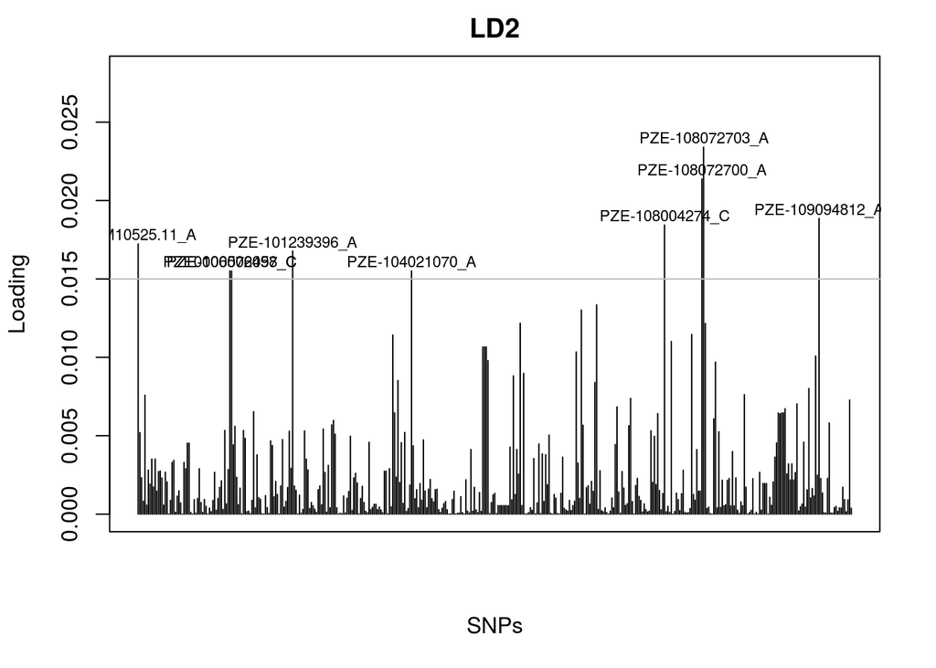

```r
loci_y<-loadingplot (dapc.fst$var.contr,threshold = 0.015, lab.jitter = 1, axis=2,xlab="SNPs",ylab="Loading",main="LD2")
```

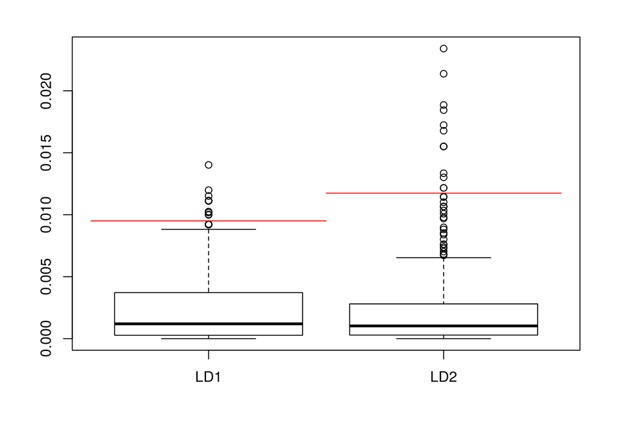

```r
boxplot(data.frame(LD1=dapc.fst$var.contr[,"LD1"],LD2=dapc.fst$var.contr[,"LD2"]))
lines(x=.5:1.5,y=rep(0.0095,2), col="red")
lines(x=1.5:2.5,y=rep(0.01173871 ,2), col="red")
```

### Altitude analysis.

The first step to perform the altitude analysis is to classify the samples according to the altitude in which they were collected. We defined a classification that divides samples in Low/High altitude with an altitudinal treshold of 750 masl, this treshold was defined from our samples. Then for every SNP $F_{ST}$ value between altitude categories is calculated to generate the set of SNPs with altitude high $F_{ST}$ and then aply a DAPC using these SNPs and the altitude classification.

```r
## Classify samples according to altitude
subject.support<-cbind(subject.support,Altoobajo=cut(subject.support[,"Altitud"],breaks<-c(0,750,2241),labels=c("bajo","alto")))
### Fst measurement for every SNP among altitudinal categories, keeping SNP name and removing NAs
faltura<-Fst(snps,subject.support[,"Altoobajo"])
names(faltura$Fst)<-colnames(snps)
faltura$Fst<-faltura$Fst[!is.na(faltura$Fst)]
##### Subset SNP matrix keeping only altitude high Fst  SNPs
altura.99<-fst.alta(faltura$Fst,.99)
snpsaltura99 <- names(altura.99$snp.info)
glmatrixalt <- glmatrix[, pmatch(snpsaltura99, colnames(glmatrix))]
glmatrixalt <- glmatrixalt[, colSums(is.na(glmatrixalt)) != nrow(glmatrixalt)]
############################################################################
## DAPC
glalt<- as.genlight(glmatrixalt)
set.seed(2)
altclusters<-find.clusters.genlight(glalt,n.pca = 48)
```

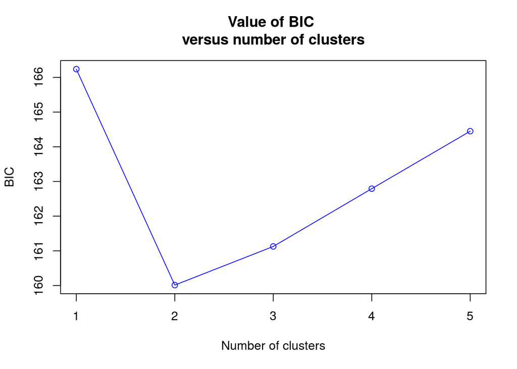

```
## Choose the number of clusters (>=2:
```

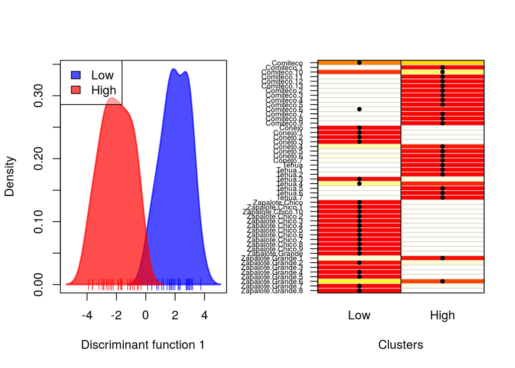

```r
altclusters<-find.clusters.genlight(glalt,n.clust=2,n.pca = 48)

dapc.alt <- dapc.genlight(glalt,altclusters$grp,n.pca=1, n.da=1)

rownames(dapc.alt$posterior)<-make.names(subject.support[,'raza'],unique=TRUE)
dapc.alt$posterior<- dapc.alt$posterior[order(rownames(dapc.alt$posterior)),]
colnames(dapc.alt$posterior)<-c("Low","High")
par(mar=c(5.1, 4.1, 4.1, 2.1),mfrow=c(1,2))
scatter(dapc.alt, legend=T, txt.leg=c("Low","High"),posi.leg="topleft")
assignplot(dapc.alt,cex.lab = 0.6,pch=NA)
points(x=as.integer(subject.support[order(subject.support[,'raza']),"Altoobajo"]),y=seq(49.5,.5,-1),pch=20)
```

## Identify altitude informative SNPs

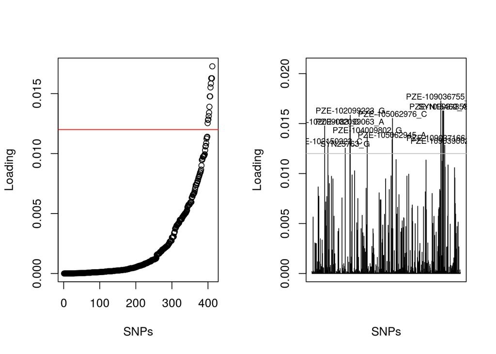

```r
rownames(dapc.alt$var.contr) <- colnames(glmatrixalt)
par(mfrow=c(1,2))
plot(sort(dapc.alt$var.contr[,"LD1"]),xlab="SNPs",ylab="Loading")
abline(h=0.012, col="red")
snpsalt<-loadingplot(dapc.alt$var.contr,threshold = 0.012,lab.jitter=1,xlab="SNPs",ylab="Loading",main="")
```

### Check for SNPs shared between the landrace and altitude informative SNPs

```r
sum(snpsalt$var.names%in%loci_x$var.names)
```

```
## [1] 5
```

```r
sum(snpsalt$var.names%in%loci_y$var.names)
```

```
## [1] 0
```

```r
snpsalt$var.names[(snpsalt$var.names%in%loci_x$var.names)]
```

```
## [1] "PZE-109036755_G" "PZE-109037166_G" "SYN15460_A"      "SYN15462_A"
## [5] "PZE-109037353_A"
```